# MODELLING REPORT

Pierre Passerotte 88941

07/06/2020

# Librairies

```r
library(readr)
library(dplyr)
```

```r
library(rpart.plot)
library(rpart)
library(caret)
library(randomForest)
library(pROC)
library(MASS)
library(ROCR)
library(pROC)
library(Ecdat)
library(party)
library(nnet)
library(AMORE)
options(tinytex.verbose = TRUE)
```

# 1) Introduction

Attribute Information:

1. White King file (column) ( a,b,c,d)
2. White King rank (row) (1,2,3,4)
3. White Rook file (a,b,c,d,e,f,g,h)
4. White Rook rank (1,2,3,4,5,6,7,8)
5. Black King file (a,b,c,d,e,f,g)
6. Black King rank (1,2,3,4,5,6,7,8)
7. optimal depth-of-win for White in 0 to 16 moves, otherwise drawn {draw, zero, one, two, …, sixteen} == TARGET

# 2) Cleaning and preprocessing data

Importing Dataset and getting an overview

```r
library(readr)
krkopt <- read_csv("https://archive.ics.uci.edu/ml/machine-learning-databases/chess/king-rook-vs-king/krkopt.data",
                   col_names = FALSE)
View(krkopt)
str(krkopt)
```

```
## Classes 'spec_tbl_df', 'tbl_df', 'tbl' and 'data.frame': 28056 obs. of  7 variables:
##  $ X1: chr  "a" "a" "a" "a" ...
##  $ X2: num  1 1 1 1 1 1 1 1 1 1 ...
##  $ X3: chr  "b" "c" "c" "c" ...
##  $ X4: num  3 1 1 1 2 2 2 2 2 3 ...
##  $ X5: chr  "c" "c" "d" "d" ...
##  $ X6: num  2 2 1 2 1 3 1 2 3 2 ...
##  $ X7: chr  "draw" "draw" "draw" "draw" ...
##  - attr(*, "spec")=
##   .. cols(
##   ..   X1 = col_character(),
##   ..   X2 = col_double(),
##   ..   X3 = col_character(),
##   ..   X4 = col_double(),
##   ..   X5 = col_character(),
##   ..   X6 = col_double(),
##   ..   X7 = col_character()
##   .. )
```

We renamed the variables here and we also mutate its format type. We decided to put everything as factor to use a maximum of models.

```r
names(krkopt)<-c("wkf","wkr","wrf","wrr","bkf","bkr","class")
krkopt=krkopt%>%mutate_if(is.character, as.factor)
krkopt=krkopt%>%mutate_if(is.numeric, as.factor)
krkopt<-na.omit(krkopt)
```

Fortunately, there isn’t missing values in this dataset.

# 3) Overview

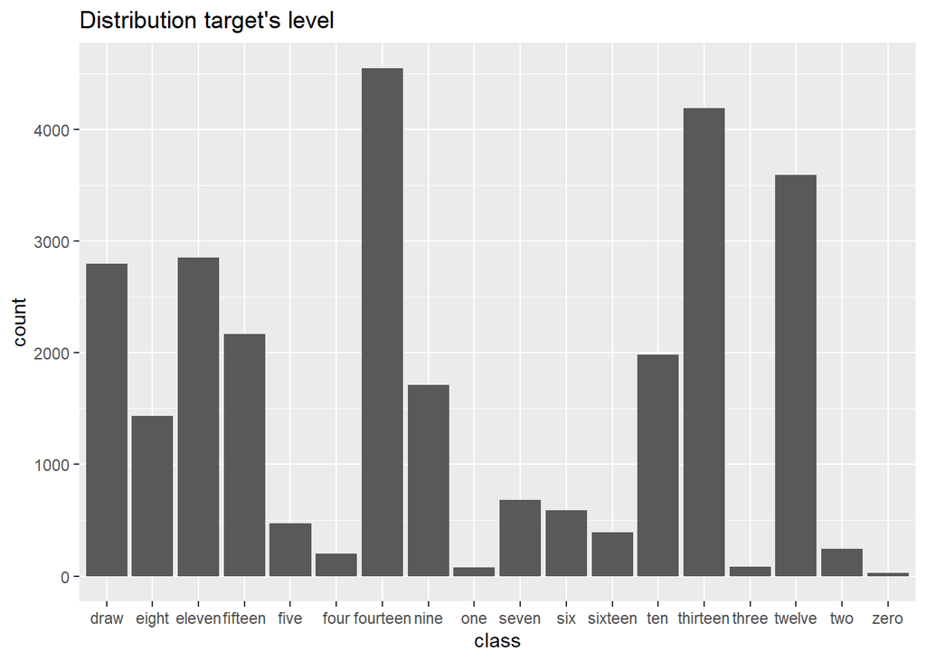

```r
gg1<-ggplot(data = krkopt) +
  geom_bar(mapping = aes(x = class)) + ggtitle("Distribution target's level")
gg1
```

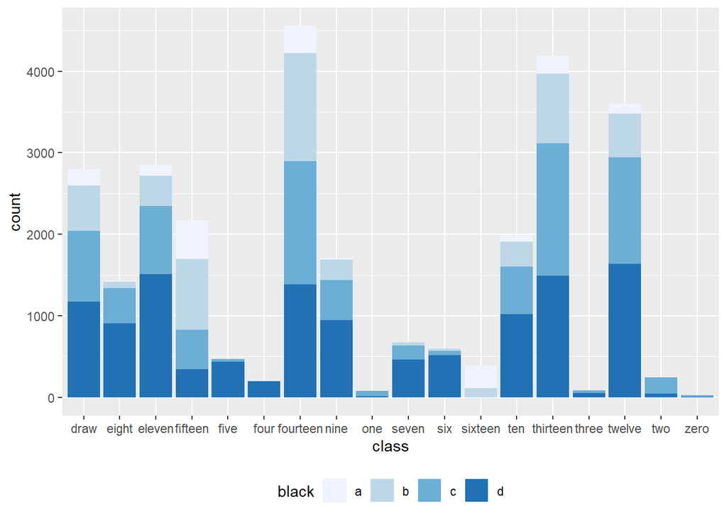

```r
ggplot(krkopt, aes(class , fill=wkf)) + geom_bar()+ scale_fill_brewer(palette())+theme(legend.position = "bottom")
```

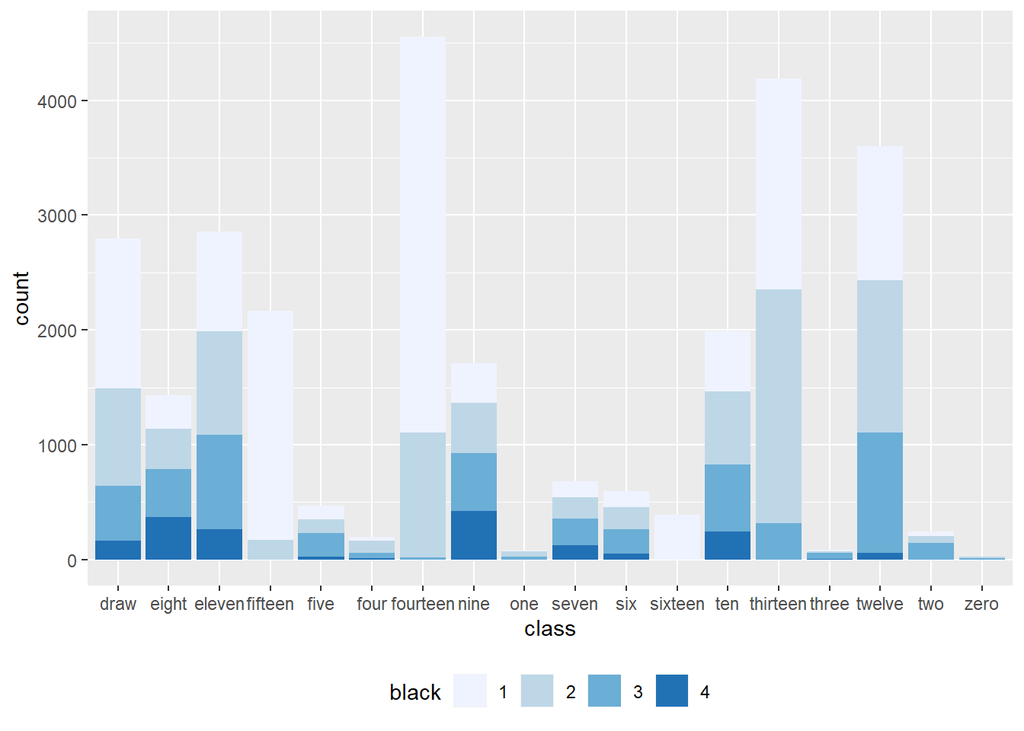

```r
ggplot(krkopt, aes(class , fill=wkr)) + geom_bar()+ scale_fill_brewer(palette())+theme(legend.position = "bottom")
```

Above, you could find repartition of file and rank across target’s level concerning White King.

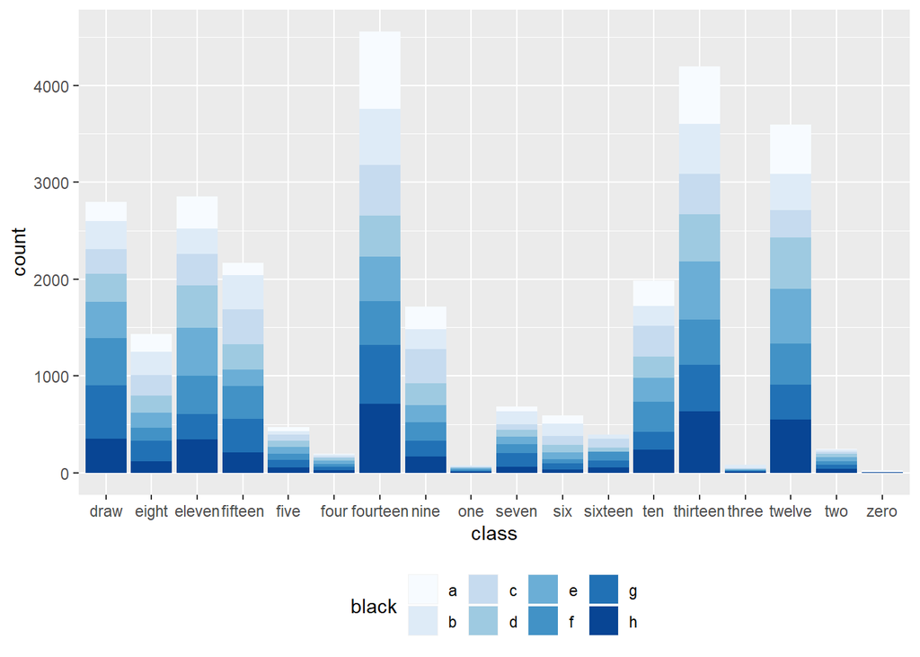

```r
ggplot(krkopt, aes(class , fill=wrf)) + geom_bar()+ scale_fill_brewer(palette())+theme(legend.position = "bottom")
```

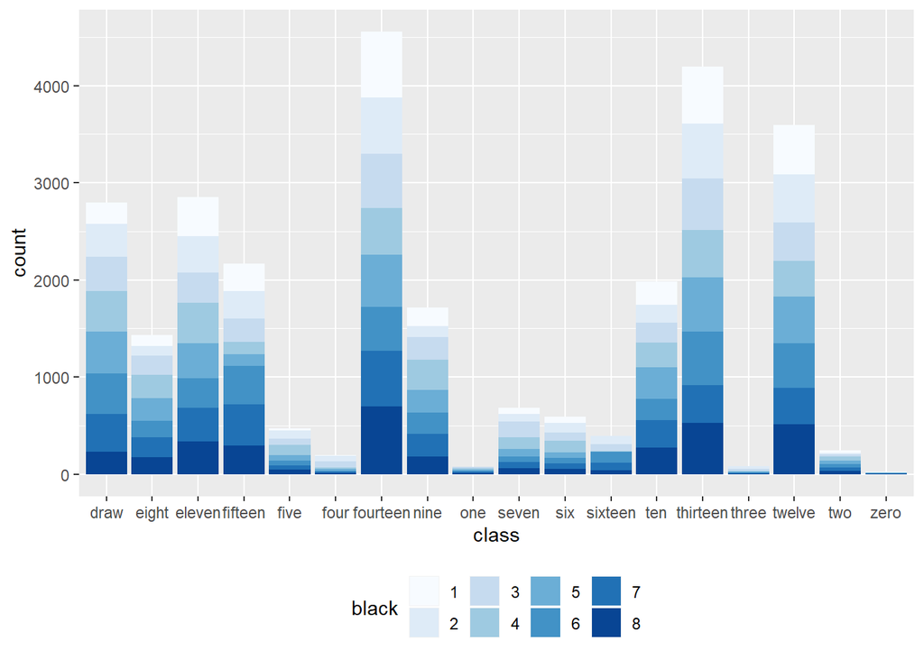

```r
ggplot(krkopt, aes(class , fill=wrr)) + geom_bar()+ scale_fill_brewer(palette())+theme(legend.position = "bottom")
```

Above, you could find repartition of file and rank across target’s level concerning white rook.

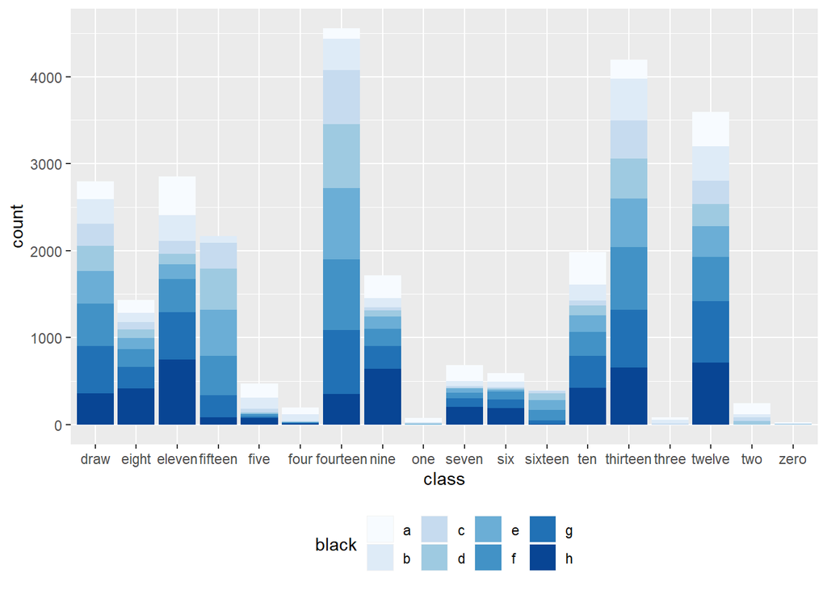

```r
ggplot(krkopt, aes(class , fill=bkf)) + geom_bar()+ scale_fill_brewer(palette())+theme(legend.position = "bottom")
```

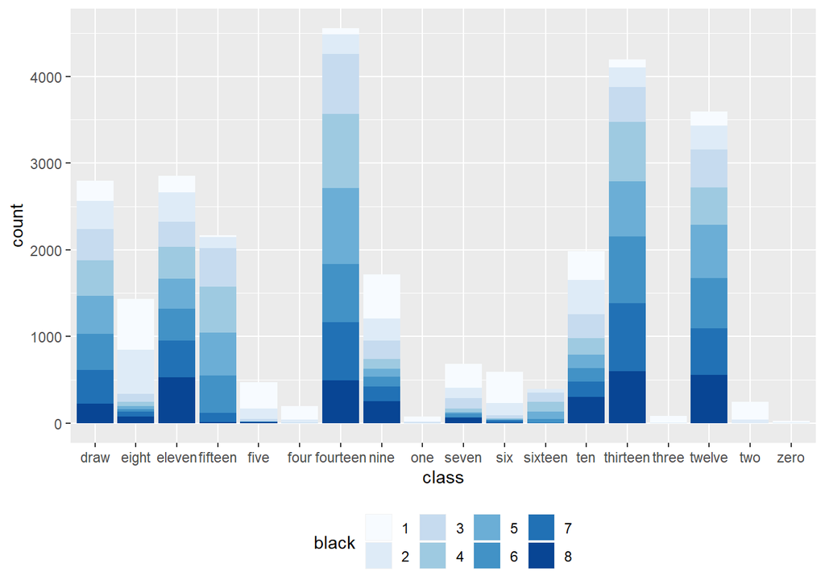

```r
ggplot(krkopt, aes(class , fill=bkr)) + geom_bar()+ scale_fill_brewer(palette())+theme(legend.position = "bottom")
```

Above, you could find repartition of file and rank across target’s level concerning black king.

Now, we can split our dataset into train and validation

```r
rand = sample(1:nrow(krkopt),0.7*nrow(krkopt))
Train = krkopt[rand,]
Val = krkopt[-rand,]
```

# 4) Model: creation and assesment

## A) Classification Tree

```r
RPART <- rpart(class ~. , data=Train, cp=0, method = "class")
cptable <- RPART$cptable
CP.OPT<-RPART$cptable[which.min(RPART$cptable[,"xerror"]),"CP"]
OPRPART<-prune(RPART, cp = CP.OPT)
RPART_pred<-predict(OPRPART, newdata=Val,type="class")
```

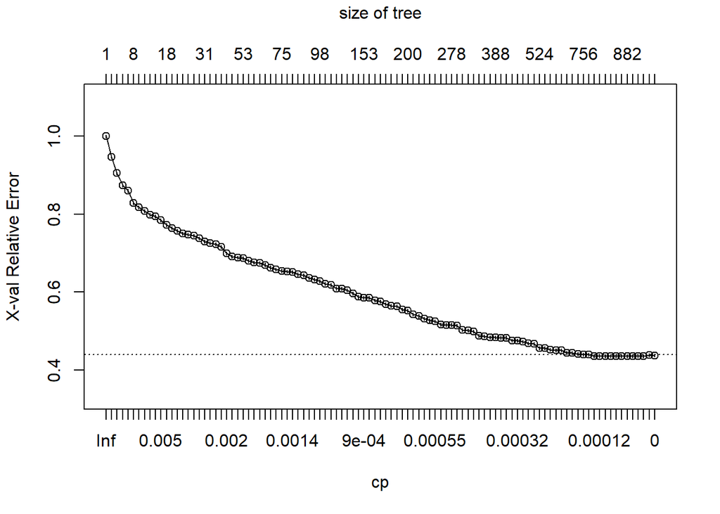

```r
plotcp(RPART)
```

Above, you could find the Complexity Parameter Table. When tree’s size increases, relative error decreases. But complexity is also decreasing too. We have to find optimal point. We calculated this optimal complexity below which is approximatively 0,00009. It refers to a size of tree between [764] and [963]. We are not surprised here because our target has seventeen levels.

```r
print(RPART$cptable[which.min(RPART$cptable[,4]),1])
```

```
## [1] 9.100837e-05
```

Then, you could find the confusionMatrix of the tree, which has 65,97% as accuracy. It is quiet good.

```r
confusionMatrix(RPART_pred, Val$class)
```

```
## Confusion Matrix and Statistics
##
##           Reference
## Prediction draw eight eleven fifteen five four fourteen nine  one seven
##   draw      362    30     54      33   11    4       79   33    1    33
##   eight      19   272      3       0    8    2        0   33    1    22
##   eleven     56    16    566       5    2    3       13   31    2     9
##   fifteen    58     0      1     505    0    0       86    0    0     0
##   five        7     3      1       0   92    4        0    5    0    12
##   four        2     0      0       0    3   45        0    0    0     2
##   fourteen   75     0     16      97    0    0     1092    1    0     1
##   nine       32    49     11       0    3    0        0  323    1     6
##   one         0     0      0       0    0    0        0    0    9     0
##   seven      16    20      0       0    4    1        0    9    1    94
##   six         2     1      0       0    7   10        0    2    0     7
##   sixteen    14     0      0       8    0    0        0    0    0     0
##   ten        26    10     57       0    1    0        3   50    0     5
##   thirteen   61     5     44       7    0    1      107   14    0     2
##   three       0     0      0       0    1    0        0    0    2     0
##   twelve     56     6     84       0    0    1       16    8    0     5
##   two         1     0      0       0    1    0        0    0    2     2
##   zero        0     0      0       0    0    0        0    0    2     2
##           Reference
## Prediction  six sixteen  ten thirteen three twelve  two zero
##   draw        8      14   35       69     1     46    6    0
##   eight       6       0   11        0     0      4    0    0
##   eleven      0       0   99       53     0    105    0    0
##   fifteen     0      13    1       15     0      9    0    0
##   five       13       0    2        0     1      1    0    2
##   four        1       0    0        0     6      0    0    0
##   fourteen    0       0   14      139     0     38    0    0
##   nine        8       0   56        0     0     12    0    0
##   one         0       0    0        0     1      0    0    0
##   seven      15       0    3        0     1      2    0    0
##   six       112       0    5        0     0      0    0    0
##   sixteen     0      92    0        2     0      1    0    0
##   ten         2       0  354        6     0     29    0    0
##   thirteen    1       0   26      833     0    143    0    0
##   three       1       0    0        0    13      0    0    0
##   twelve      0       0   25      130     0    728    0    0
```

[output cut: 46 more lines]

```
## Pos Pred Value          0.65193         0.66961     0.764706       0.68744
## Neg Pred Value          0.96482         0.94228     0.998690       0.94700
## Prevalence              0.07497         0.14815     0.002851       0.13283
## Detection Rate          0.04206         0.09897     0.001544       0.08649
## Detection Prevalence    0.06451         0.14780     0.002020       0.12582
## Balanced Accuracy       0.76837         0.80534     0.770595       0.80291
##                      Class: two Class: zero
## Sensitivity            0.907895   0.4000000
## Specificity            0.998441   0.9994053
## Pos Pred Value         0.841463   0.4444444
## Neg Pred Value         0.999160   0.9992864
## Prevalence             0.009029   0.0011881
## Detection Rate         0.008198   0.0004752
## Detection Prevalence   0.009742   0.0010693
## Balanced Accuracy      0.953168   0.6997026
```

We did not plot the tree or print the decision rules. The results were toog long because of the multiple target’s level. But It said that Wkf was the primary variable who entered in decision.

## B) Random Forest

```r
Model <- randomForest(class~., data=Train, ntrees=200)
pred<-predict(Model, newdata=Val)
confusionMatrix(pred,Val$class)
```

```
## Confusion Matrix and Statistics
##
##           Reference
## Prediction draw eight eleven fifteen five four fourteen nine  one seven
##   draw      460    20     36       4    5    5        5   22    0    20
##   eight      10   305      1       0    5    1        0   39    1    26
##   eleven     33    10    607       1    1    2        6   38    0    11
##   fifteen    60     0      2     529    0    0       61    0    0     0
##   five        1     1      2       0  100    7        0    6    2     2
##   four        0     0      0       0    2   48        0    0    0     0
##   fourteen   81     2     33     114    0    0     1210    5    0     2
##   nine       14    50      4       0    3    0        0  343    4    11
##   one         0     0      0       0    0    0        0    0   12     0
##   seven       4     5      0       0    4    0        0    1    1   102
##   six         0     1      0       0    7    7        0    3    0     5
##   sixteen    10     0      0       2    0    0        1    0    0     0
##   ten         9     7     21       0    2    0        4   28    0     8
##   thirteen   53     3     36       4    1    1       89   11    0     1
##   three       1     0      0       0    0    0        0    0    0     0
##   twelve     48     8     95       1    1    0       20   13    0     9
##   two         3     0      0       0    2    0        0    0    1     5
##   zero        0     0      0       0    0    0        0    0    0     0
##           Reference
## Prediction  six sixteen  ten thirteen three twelve  two zero
##   draw        9       1   23        9     0     16    0    2
##   eight      14       0   15        0     0      3    0    0
##   eleven      3       0  110       21     0     92    0    0
##   fifteen     0      34    0       18     0      8    0    0
##   five        6       0    4        0     2      0    1    0
##   four        1       0    0        0     6      0    0    0
##   fourteen    0       4   13      154     0     44    0    0
##   nine        6       0   35        1     0      4    0    0
##   one         0       0    0        0     0      0    0    0
##   seven      12       0    3        0     1      0    0    0
##   six       114       0    3        0     0      3    0    0
##   sixteen     0      80    0        1     0      0    0    0
##   ten         2       0  359        2     0     17    0    0
##   thirteen    1       0   24      938     0    111    0    0
##   three       0       0    0        0     8      0    1    0
##   twelve      0       0   42      103     0    820    0    0
```

[output cut: 46 more lines]

```
## Pos Pred Value          0.78214          0.7368    0.8000000       0.70690
## Neg Pred Value          0.96582          0.9567    0.9980968       0.95894
## Prevalence              0.07497          0.1482    0.0028514       0.13283
## Detection Rate          0.04265          0.1114    0.0009505       0.09742
## Detection Prevalence    0.05453          0.1512    0.0011881       0.13782
## Balanced Accuracy       0.77805          0.8527    0.6665475       0.84344
##                      Class: two Class: zero
## Sensitivity            0.973684   0.4000000
## Specificity            0.997243   1.0000000
## Pos Pred Value         0.762887   1.0000000
## Neg Pred Value         0.999760   0.9992868
## Prevalence             0.009029   0.0011881
## Detection Rate         0.008792   0.0004752
## Detection Prevalence   0.011524   0.0004752
## Balanced Accuracy      0.985463   0.7000000
```

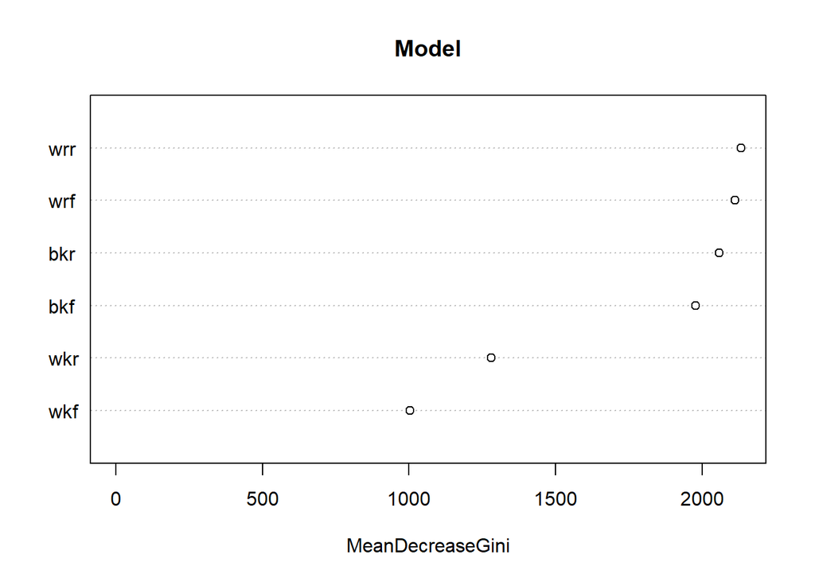

```r
varImpPlot(Model)
```

## C) Multinomial Logistic regression

Now, let’s run a logistic regression.

```r
multi<- multinom(class ~., family=binomial(logit), data=Train, control = list(maxit = 50))
multi.prediction = predict(multi, Val, type= 'class')
pred.obs=data.frame(multi.prediction=multi.prediction, Val$class)
ctable1<- table(Val$class, multi.prediction)
```

```r
confusionMatrix(multi.prediction, Val$class)
```

```
## Confusion Matrix and Statistics
##
##           Reference
## Prediction draw eight eleven fifteen five four fourteen nine one seven six
##   draw       75     8     82      19    1    0       91   17   0     7   1
##   eight      36   195     21       0    7    5        1   78   1    49  33
##   eleven     40    30    218       1    2    2       13   98   0    16   8
##   fifteen    74     0      6     383    0    0       71    0   0     0   0
##   five       11     3      6       0   72   31        0    7   1     3  22
##   four        1     0      1       0    3   17        0    0   0     1   1
##   fourteen  182    12     71     217    0    0      902   18   0     4   0
##   nine       20    77     55       0    4    2        0  155   1    33  10
##   one         0     0      0       0    0    0        0    0   1     0   0
##   seven      15    11      3       0    9    0        0    5   1    25   8
##   six        15    19      2       0   23   14        0    6   0    14  71
##   sixteen    11     0      2       4    0    0        8    0   0     0   0
##   ten        24    23     52       0    8    0        4   47   1    14   5
##   thirteen  181    11    117      30    0    0      287   26   0    10   1
##   three       3     0      0       0    0    0        0    0   1     1   2
##   twelve     95    19    195       1    1    0       19   46   0    22   5
##   two         4     4      6       0    3    0        0    6  14     3   2
##   zero        0     0      0       0    0    0        0    0   0     0   0
##           Reference
## Prediction sixteen ten thirteen three twelve two zero
##   draw           0  53      105     0    111   0    0
##   eight          0  55        1     0     13   6    1
##   eleven         0 157       53     0    126   0    0
##   fifteen       45   2       38     0     11   0    0
##   five           0   1        2     4      0   4    0
##   four           0   0        0     4      2   1    0
##   fourteen       2  34      301     0     76   0    0
##   nine           0  84        7     0     21   0    0
##   one            0   0        0     0      0   0    0
##   seven          0   7        3     2      1   0    0
##   six            0   3        0     6      1   2    1
##   sixteen       72   0        3     0      0   0    0
##   ten            0  84        5     0     22   1    2
##   thirteen       0  54      576     0    351   0    0
##   three          0   1        1     1      0   3    0
##   twelve         0  92      152     0    381   0    0
```

[output cut: 46 more lines]

```
## Pos Pred Value          0.28767         0.35036    0.0769231       0.37062
## Neg Pred Value          0.93268         0.90093    0.9972632       0.90026
## Prevalence              0.07497         0.14815    0.0028514       0.13283
## Detection Rate          0.00998         0.06843    0.0001188       0.04527
## Detection Prevalence    0.03469         0.19532    0.0015445       0.12213
## Balanced Accuracy       0.55320         0.65648    0.5201185       0.62607
##                      Class: two Class: zero
## Sensitivity            0.776316    0.000000
## Specificity            0.992687    1.000000
## Pos Pred Value         0.491667         NaN
## Neg Pred Value         0.997951    0.998812
## Prevalence             0.009029    0.001188
## Detection Rate         0.007010    0.000000
## Detection Prevalence   0.014257    0.000000
## Balanced Accuracy      0.884501    0.500000
```

To avoid overfitting, we could maybe try to order our targets level.

## D) Ordinal Logistic regression

Now, let’s try to order our target variable from “draw” to “sixteen”

```r
krkopt$class <- factor(krkopt$class, levels=c("draw","zero", "one", "two","three", "four" , "five","six", "seven", "eight", "nine", "ten", "eleven", "twelve" , "thirteen", "fourteen" , "fifteen" ,"sixteen"), ordered=TRUE)
```

Then, splitting dataset again

```r
rand = sample(1:nrow(krkopt),0.7*nrow(krkopt))
Training.Ordinal = krkopt[rand,]
Validation.Ordinal = krkopt[-rand,]
```

Now, we are applying for an ordinal logistic regression. We could find below summary statistics concerning regression. I do not understand why this summary does not display p-values of my coefficents. I would have like to see which coefficients are significants or not.

```r
polrMod <- polr(class ~. , data=Training.Ordinal)
summary(polrMod)$coef
```

```
##
## Re-fitting to get Hessian
```

```
##                         Value Std. Error    t value
## wkfb              -1.10544308 0.06475630 -17.070820
## wkfc              -1.73204651 0.06421975 -26.970620
## wkfd              -2.06859737 0.06532051 -31.668423
## wkr2              -1.09091334 0.03143679 -34.701804
## wkr3              -1.84985535 0.03898036 -47.456085
## wkr4              -1.97824435 0.05803334 -34.088065
## wrfb               0.04885490 0.04815953   1.014439
## wrfc               0.11336562 0.04854581   2.335230
## wrfd              -0.12703605 0.04836865  -2.626413
## wrfe              -0.26185767 0.04703075  -5.567798
## wrff              -0.03520180 0.04861234  -0.724133
## wrfg              -0.07704962 0.04947637  -1.557301
## wrfh               0.12318124 0.04708605   2.616088
## wrr2              -0.15712696 0.04832186  -3.251674
## wrr3              -0.31043925 0.04829348  -6.428182
## wrr4              -0.72624814 0.04840200 -15.004507
## wrr5              -0.49762108 0.04807574 -10.350774
## wrr6               0.07593609 0.04916308   1.544575
## wrr7               0.10605728 0.04926975   2.152584
## wrr8               0.10366610 0.04766424   2.174924
## bkfb               0.92297034 0.05437849  16.973078
## bkfc               2.00047410 0.05841787  34.244214
## bkfd               2.37413329 0.05709855  41.579569
## bkfe               2.35079348 0.05418750  43.382576
## bkff               1.95439593 0.05134690  38.062588
## bkfg               1.37233878 0.04957595  27.681544
## bkfh               0.59217885 0.04762839  12.433317
## bkr2               0.95114718 0.04905042  19.391213
## bkr3               2.51021569 0.05197493  48.296662
## bkr4               3.10031241 0.05256678  58.978551
## bkr5               3.13644795 0.05260262  59.625317
## bkr6               2.98213932 0.05264561  56.645548
## bkr7               2.53562416 0.05279040  48.031914
## bkr8               2.12463141 0.05243449  40.519727
## draw|zero         -2.70124332 0.08942721 -30.206057
## zero|one          -2.68931359 0.08939630 -30.083052
## one|two           -2.65853075 0.08932219 -29.763384
## two|three         -2.56481916 0.08913398 -28.774875
## three|four        -2.53603303 0.08908605 -28.467230
## four|five         -2.45640522 0.08897235 -27.608635
## five|six          -2.27770144 0.08879986 -25.649832
## six|seven         -2.06064539 0.08869394 -23.233214
## seven|eight       -1.82539938 0.08864831 -20.591474
## eight|nine        -1.35411054 0.08862888 -15.278434
## nine|ten          -0.83156079 0.08872301  -9.372549
## ten|eleven        -0.26822407 0.08899531  -3.013913
## eleven|twelve      0.48400700 0.08953382   5.405857
## twelve|thirteen    1.38078588 0.09031316  15.288867
## thirteen|fourteen  2.52387923 0.09134421  27.630423
## fourteen|fifteen   4.25133618 0.09342271  45.506455
## fifteen|sixteen    6.60618470 0.10726324  61.588525
```

```r
predictedClass <- predict(polrMod, Validation.Ordinal, type="class")
ctabletest <- table(Validation.Ordinal$class, predictedClass)
```

Below, you can find the accuracy of our model.

```r
round((sum(diag(ctabletest))/sum(ctabletest))*100,2)
```

```
## [1] 30.62
```

# 5) Conclusion

Concerning both logistic regression (multinomial and ordinal), we suppose that they are both overfitted. Accuracy for multinomial and oridnal models arerespectively 40% and 30%. When I tried to decrease his complexity by ommitting white king’s position (“wkr”,“wkf”), I found worse results. I think that our target has too many level to get significant result.

I would have like to create more plot to asses my models but our multiclass target variable did not allow it. For exemple, I did not find a proper way to present a ROC curve with more than 2 outcome’s level. Then, I also did not manage to plot my tree because it contained too many splits and branchs. So it would have been maybe preferable to analyse this dataset as an binary outcome (draw, victory).